## Computer Vision Interpret

`vision.interpret` is the module that implements custom `Interpretation` classes for different vision tasks by inheriting from it.

`class` `SegmentationInterpretation`[[source]](https://github.com/fastai/fastai/blob/master/fastai/vision/interpret.py#L10)[test]

> `SegmentationInterpretation`(**`learn`**:`Learner`, **`preds`**:`Tensor`, **`y_true`**:`Tensor`, **`losses`**:`Tensor`, **`ds_type`**:`DatasetType`=*`<DatasetType.Valid: 2>`*) :: `Interpretation`

×

No tests found for `SegmentationInterpretation`. To contribute a test please refer to this guide and [this discussion](https://forums.fast.ai/t/improving-expanding-functional-tests/32929).

Interpretation methods for segmenatation models.

`top_losses`[[source]](https://github.com/fastai/fastai/blob/master/fastai/vision/interpret.py#L19)[test]

> `top_losses`(**`sizes`**:`Tuple`, **`k`**:`int`=*`None`*, **`largest`**=*`True`*)

×

No tests found for `top_losses`. To contribute a test please refer to this guide and [this discussion](https://forums.fast.ai/t/improving-expanding-functional-tests/32929).

Reduce flatten loss to give a single loss value for each image

`_interp_show`[[source]](https://github.com/fastai/fastai/blob/master/fastai/vision/interpret.py#L24)[test]

> `_interp_show`(**`ims`**:`ImageSegment`, **`classes`**:`Collection`[`T_co`]=*`None`*, **`sz`**:`int`=*`20`*, **`cmap`**=*`'tab20'`*, **`title_suffix`**:`str`=*`None`*)

×

No tests found for `_interp_show`. To contribute a test please refer to this guide and [this discussion](https://forums.fast.ai/t/improving-expanding-functional-tests/32929).

Show ImageSegment with color mapping labels

`show_xyz`[[source]](https://github.com/fastai/fastai/blob/master/fastai/vision/interpret.py#L53)[test]

> `show_xyz`(**`i`**, **`classes`**:`list`=*`None`*, **`sz`**=*`10`*)

×

No tests found for `show_xyz`. To contribute a test please refer to this guide and [this discussion](https://forums.fast.ai/t/improving-expanding-functional-tests/32929).

show (image, true and pred) from self.ds with color mappings, optionally only plot

`_generate_confusion`[[source]](https://github.com/fastai/fastai/blob/master/fastai/vision/interpret.py#L60)[test]

> `_generate_confusion`()

×

No tests found for `_generate_confusion`. To contribute a test please refer to this guide and [this discussion](https://forums.fast.ai/t/improving-expanding-functional-tests/32929).

Average and Per Image Confusion: intersection of pixels given a true label, true label sums to 1

`_plot_intersect_cm`[[source]](https://github.com/fastai/fastai/blob/master/fastai/vision/interpret.py#L79)[test]

> `_plot_intersect_cm`(**`cm`**, **`title`**=*`'Intersection with Predict given True'`*)

×

No tests found for `_plot_intersect_cm`. To contribute a test please refer to this guide and [this discussion](https://forums.fast.ai/t/improving-expanding-functional-tests/32929).

Plot confusion matrices: self.mean_cm or self.single_img_cm generated by `_generate_confusion`

Let's show how `SegmentationInterpretation` can be used once we train a segmentation model.

### train

```python
camvid = untar_data(URLs.CAMVID_TINY)
path_lbl = camvid/'labels'
path_img = camvid/'images'
```

```python
codes = np.loadtxt(camvid/'codes.txt', dtype=str)
get_y_fn = lambda x: path_lbl/f'{x.stem}_P{x.suffix}'
```

```python
data = (SegmentationItemList.from_folder(path_img)
        .split_by_rand_pct()
        .label_from_func(get_y_fn, classes=codes)
        .transform(get_transforms(), tfm_y=True, size=128)
        .databunch(bs=16, path=camvid)
        .normalize(imagenet_stats))
```

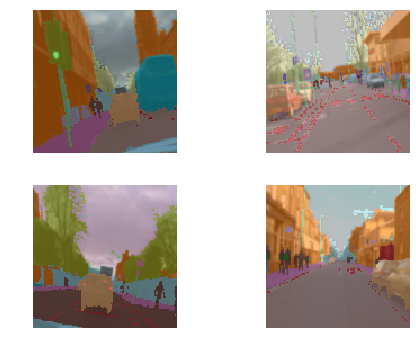

```python
data.show_batch(rows=2, figsize=(7,5))
```

```python
learn = unet_learner(data, models.resnet18)
learn.fit_one_cycle(3,1e-2)
learn.save('mini_train')
```

| epoch | train_loss | valid_loss | time |
| --- | --- | --- | --- |
| 0 | 10.024513 | 3.442348 | 00:15 |
| 1 | 6.325253 | 2.343699 | 00:03 |
| 2 | 4.759998 | 2.108100 | 00:02 |

**Warning:** Following results will not make much sense with this underperforming model but functionality will be explained with ease

### interpret

```python
interp = SegmentationInterpretation.from_learner(learn)
```

Since `FlattenedLoss of CrossEntropyLoss()` is used we reshape and then take the mean of pixel losses per image. In order to do so we need to pass `sizes:tuple` to `top_losses()`

```python
top_losses, top_idxs = interp.top_losses(sizes=(128,128))
```

```
(tensor([3.3195, 3.1692, 2.6574, 2.5976, 2.4910, 2.3759, 2.3710, 2.2064, 2.0871,
         2.0834, 2.0479, 1.8645, 1.8412, 1.7956, 1.7013, 1.6126, 1.6015, 1.5470,
         1.4495, 1.3423]),
 tensor([12,  4, 17, 13, 19, 18,  7,  8, 10,  1, 15,  0,  2,  9, 16, 11, 14,  5,
          6,  3]))
```

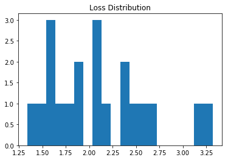

Next, we can generate a confusion matrix similar to what we usually have for classification. Two confusion matrices are generated: `mean_cm` which represents the global label performance and `single_img_cm` which represents the same thing but for each individual image in dataset.

Values in the matrix are calculated as:

\begin{align} \ CM_{ij} & = IOU(Predicted , True | True) \\ \end{align}

Or in plain english: ratio of pixels of predicted label given the true pixels

```python
learn.data.classes
```

```
array(['Animal', 'Archway', 'Bicyclist', 'Bridge', 'Building', 'Car', 'CartLuggagePram', 'Child', 'Column_Pole',
       'Fence', 'LaneMkgsDriv', 'LaneMkgsNonDriv', 'Misc_Text', 'MotorcycleScooter', 'OtherMoving', 'ParkingBlock',
       'Pedestrian', 'Road', 'RoadShoulder', 'Sidewalk', 'SignSymbol', 'Sky', 'SUVPickupTruck', 'TrafficCone',
       'TrafficLight', 'Train', 'Tree', 'Truck_Bus', 'Tunnel', 'VegetationMisc', 'Void', 'Wall'], dtype='<U17')
```

```python
mean_cm, single_img_cm = interp._generate_confusion()
```

```
((32, 32), (20, 32, 32))
```

`_plot_intersect_cm` first displays a dataframe showing per class score using the IOU definition we made earlier. These are the diagonal values from the confusion matrix which is displayed after.

`NaN` indicate that these labels were not present in our dataset, in this case validation set. As you can imagine it also helps you to maybe construct a better representing validation set.

| label | score |
| --- | --- |
| Sky | 0.851616 |
| Road | 0.793361 |
| Building | 0.274023 |
| Tree | 0.00469498 |
| Void | 6.70092e-05 |
| Animal | 0 |
| Pedestrian | 0 |
| VegetationMisc | 0 |
| Truck_Bus | 0 |
| TrafficLight | 0 |
| SUVPickupTruck | 0 |
| SignSymbol | 0 |
| Sidewalk | 0 |
| ParkingBlock | 0 |
| Archway | 0 |
| OtherMoving | 0 |
| Misc_Text | 0 |
| LaneMkgsDriv | 0 |
| Fence | 0 |
| Column_Pole | 0 |
| Child | 0 |
| CartLuggagePram | 0 |
| Car | 0 |
| Bicyclist | 0 |
| Wall | 0 |
| Bridge | NaN |
| LaneMkgsNonDriv | NaN |
| MotorcycleScooter | NaN |
| RoadShoulder | NaN |
| TrafficCone | NaN |
| Train | NaN |
| Tunnel | NaN |

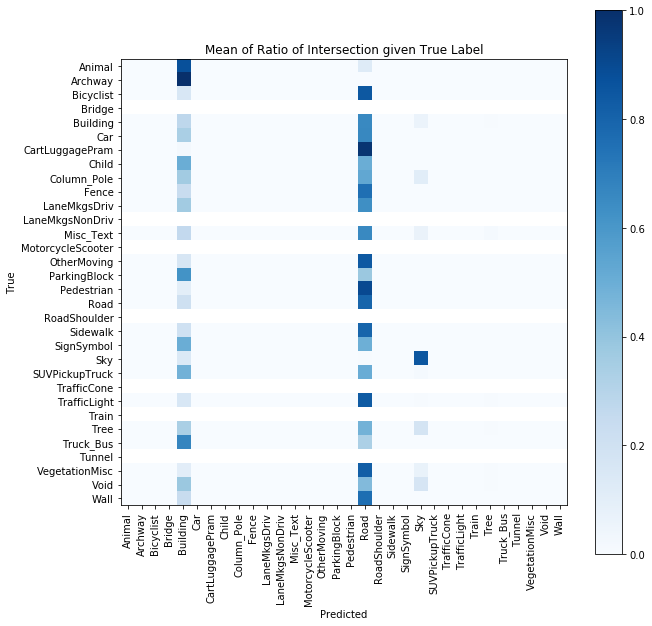

```python
df = interp._plot_intersect_cm(mean_cm, "Mean of Ratio of Intersection given True Label")
```

Next let's look at the single worst prediction in our dataset. It looks like this dummy model just predicts everything as `Road` :)

| label | score |
| --- | --- |
| Road | 0.999367 |
| Sky | 0.405882 |
| Building | 0.0479275 |
| Tree | 0.00365813 |
| Bicyclist | 0 |
| Void | 0 |
| TrafficLight | 0 |
| SUVPickupTruck | 0 |
| Sidewalk | 0 |
| Pedestrian | 0 |
| OtherMoving | 0 |
| Misc_Text | 0 |
| LaneMkgsDriv | 0 |
| Column_Pole | 0 |
| CartLuggagePram | 0 |
| Car | 0 |
| Wall | 0 |
| Animal | NaN |
| Archway | NaN |
| Bridge | NaN |
| Child | NaN |
| Fence | NaN |
| LaneMkgsNonDriv | NaN |
| MotorcycleScooter | NaN |
| ParkingBlock | NaN |
| RoadShoulder | NaN |
| SignSymbol | NaN |
| TrafficCone | NaN |
| Train | NaN |
| Truck_Bus | NaN |
| Tunnel | NaN |
| VegetationMisc | NaN |

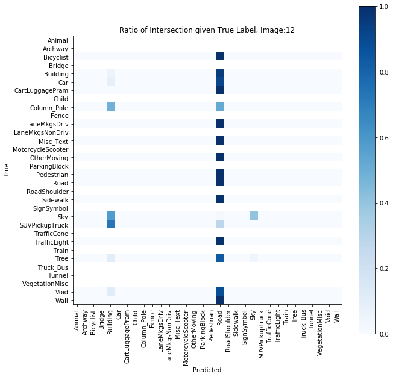

```python
i = top_idxs[0]
df = interp._plot_intersect_cm(single_img_cm[i], f"Ratio of Intersection given True Label, Image:{i}")
```

Finally we will visually inspect this single prediction

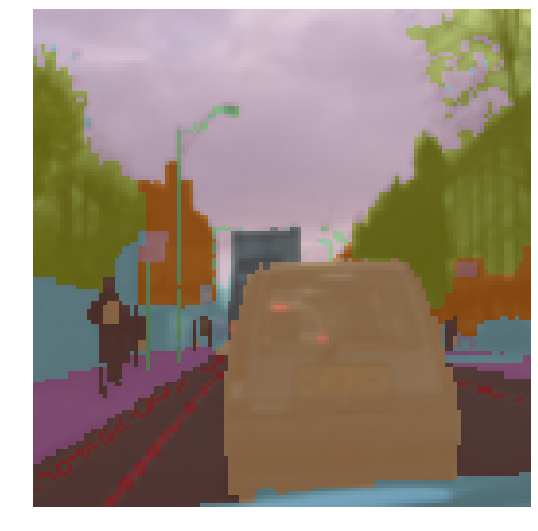

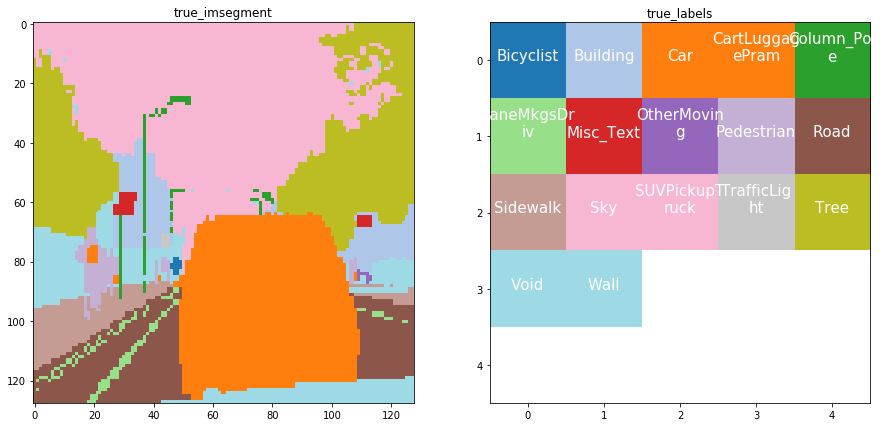

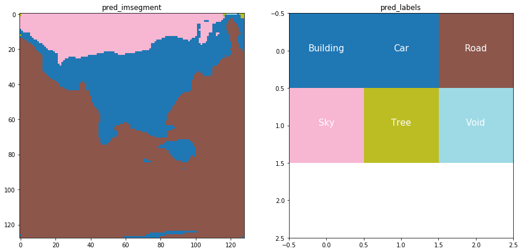

```python
interp.show_xyz(i, sz=15)
```

**Warning:** With matplotlib colormaps the max number of unique qualitative colors is 20. So if len(classes) > 20 then close class indexes may be plotted with the same color. Let's fix this together :)

```
{'Animal': 0,
 'Archway': 1,
 'Bicyclist': 2,
 'Bridge': 3,
 'Building': 4,
 'Car': 5,
 'CartLuggagePram': 6,
 'Child': 7,
 'Column_Pole': 8,
 'Fence': 9,
 'LaneMkgsDriv': 10,
 'LaneMkgsNonDriv': 11,
 'Misc_Text': 12,
 'MotorcycleScooter': 13,
 'OtherMoving': 14,
 'ParkingBlock': 15,
 'Pedestrian': 16,
 'Road': 17,
 'RoadShoulder': 18,
 'Sidewalk': 19,
 'SignSymbol': 20,
 'Sky': 21,
 'SUVPickupTruck': 22,
 'TrafficCone': 23,
 'TrafficLight': 24,
 'Train': 25,
 'Tree': 26,
 'Truck_Bus': 27,
 'Tunnel': 28,
 'VegetationMisc': 29,
 'Void': 30,
 'Wall': 31}
```

`class` `ObjectDetectionInterpretation`[[source]](https://github.com/fastai/fastai/blob/master/fastai/vision/interpret.py#L101)[test]

> `ObjectDetectionInterpretation`(**`learn`**:`Learner`, **`preds`**:`Tensor`, **`y_true`**:`Tensor`, **`losses`**:`Tensor`, **`ds_type`**:`DatasetType`=*`<DatasetType.Valid: 2>`*) :: `Interpretation`

×

No tests found for `ObjectDetectionInterpretation`. To contribute a test please refer to this guide and [this discussion](https://forums.fast.ai/t/improving-expanding-functional-tests/32929).

Interpretation methods for classification models.

**Warning:** ObjectDetectionInterpretation is not implemented yet. Feel free to implement it :)